# STATS 769 Lab1

Xuan Fang

8/4/2020

# Task 1

Import the six CSV files (COVID-19 cases from around the world from January to June, 2020) into R and combine them into a single data frame.

```r
## Read into R and combine the datasets
covid.df <- do.call(rbind, lapply(sprintf("covid-0%d.csv", 1:6), FUN=read.csv))

## Exploration
str(covid.df)
```

```
## 'data.frame':    339547 obs. of  33 variables:
##  $ ID                      : Factor w/ 339547 levels "000-1-10047",..: 1 2 3 4 5 6 7 8 9 10 ...
##  $ age                     : chr  "45" NA "62" NA ...
##  $ sex                     : Factor w/ 3 levels "","female","male": 3 NA 2 NA 3 2 2 3 3 2 ...
##  $ city                    : Factor w/ 4550 levels "","Ankang City",..: 160 4 170 3 117 117 117 117 117 117 ...
##  $ province                : Factor w/ 716 levels "","Anhui","Bangkok Metropolis",..: 26 17 60 2 2 2 2 2 2 2 ...
##  $ country                 : Factor w/ 105 levels "","Australia",..: 4 4 4 4 4 4 4 4 4 4 ...
##  $ latitude                : num  43.8 35.9 25.3 30.6 31.6 ...
##  $ longitude               : num  123.7 114.4 98.5 116.6 118.4 ...
##  $ geo_resolution          : Factor w/ 6 levels "admin0","admin1",..: 4 3 4 3 3 3 3 3 3 3 ...
##  $ date_onset_symptoms     : Factor w/ 159 levels "","01.01.2020",..: 3 1 1 1 22 19 18 22 18 22 ...
##  $ date_admission_hospital : Factor w/ 92 levels "","02.02.2020",..: 26 1 22 1 18 19 18 19 20 20 ...
##  $ date_confirmation       : Factor w/ 148 levels "01.02.2020","02.02.2020",..: 10 21 7 21 20 20 20 20 21 21 ...
##  $ symptoms                : Factor w/ 250 levels "","aching muscles, fever, pneumonia",..: 1 1 1 1 61 61 61 61 61 29 ...
##  $ lives_in_Wuhan          : Factor w/ 3 levels "","no","yes": 1 1 3 1 3 3 3 3 2 3 ...
```

[output cut: 19 more lines]

## Commentary:

- The six files we intend to import are CSV (comma-separated-value) files, so we use read.csv() function to import them into R. After reading the six files, we end up with 6 data frames.
- Then we use `rbind()` function combine the six data frames by rows into a single data frame.

# Task 2

Create `deceased` variable.

Exploring the levels of `outcome` variable:

```r
levels(covid.df$outcome)
```

```
##  [1] ""                         "death"
##  [3] "died"                     "discharge"
##  [5] "discharged"               "Discharged"
##  [7] "recovered"                "Recovered"
##  [9] "released from quarantine" "Died"
## [11] "stable"                   "Alive"
## [13] "Dead"                     "Death"
## [15] "Deceased"                 "Hospitalized"
## [17] "Receiving Treatment"      "severe illness"
## [19] "Stable"                   "stable condition"
## [21] "Under treatment"          "unstable"
## [23] "critical condition"       "dead"
```

## Commentary:

- We find seven values in the `outcome` column could represent the failure to survive, which are: “death”, “died”, “Died”, “Dead”, “Death”, “Deceased” and “dead”.
- Therefore, if the `outcome` value matches one of the seven values, then set the `deceased` value to be ‘TRUE’; and, everything else to be ‘FALSE’.

```r
## Creating the `deceased` variable:
covid.df$deceased <- covid.df$outcome %in% c("death", "died", "Died", "Dead",
                                                    "Death", "Deceased", "dead")

## Exploration: the total number of death (1295):
table(covid.df$deceased)
```

```
##
##  FALSE   TRUE
## 338252   1295
```

# Task 3

Generate a new variable `years` from the `age` variable that only contains numeric values between 1 and 99 (inclusive)

```r
## Notice that there are integer and fractional years and texts in the `age` column
table(covid.df$age)
```

```
##
##            0          0.1          0.2         0.25          0.3          0.4
##         1468           13            3            3            3            1
##          0.5      0.58333          0.6 0.6666666667          0.7         0.75
##            5            2            1            2            3            1
##          0.9            1          1.5         1.75           10          100
##            2          858            8            2          933           19
##          101          102          103          104          105          106
##            7            6            4            3            5            1
##           11     11 month           12          120          121           13
##          928            1          956            3            1         1038
##     13 month           14           15           16           17           18
##            1         1009         1143         1275         1527         2267
##     18 month    18 months           19            2          2.5           20
##            2            1         3121          700            5         4027
```

[output cut: 36 more lines]

```r
## Exploration: the total number of NAs in the 'age' variable:
sum(is.na(covid.df$age))
```

```
## [1] 234
```

```r
## Creating the new variable 'years' by keeping the integer and fractional years (between 1 and 99)
## and, turn everything else into NA:
covid.df$years <- as.numeric(covid.df$age)
covid.df$years <- ifelse(covid.df$years>=1 & covid.df$years<=99, covid.df$years, NA)
## Have a look at the new variable 'years'
table(covid.df$years)
```

```
##
##    1  1.5 1.75    2  2.5    3  3.5    4    5    6    7    8    9   10   11   12
##  858    8    2  700    5  718    3  660  656  677  746  791  746  933  928  956
##   13   14   15   16   17   18   19   20   21   22   23   24   25   26   27   28
## 1038 1009 1143 1275 1527 2267 3121 4027 4213 4676 5167 5750 6364 6464 6761 6942
##   29 29.6   30   31   32   33   34   35   36   37   38   39   40   41   42   43
## 7021    1 7436 7294 7360 6894 6729 7090 6468 6742 6816 6495 6649 5949 6306 6302
##   44   45   46   47   48   49   50   51   52   53   54 54.9   55   56   57   58
## 6080 6402 5947 5962 5952 5778 5911 5294 5548 5138 5241    1 5201 4827 4589 4404
##   59   60   61   62   63   64   65   66   67   68   69   70   71   72   73   74
## 4018 4114 3332 3269 3040 2970 3141 2536 2532 2396 2222 2163 1793 1962 1760 1432
##   75   76   77   78   79   80   81   82   83   84   85   86   87   88   89   90
## 1482 1278 1260 1060 1014 1052  832  844  760  659  603  479  419  441  365  295
##   91   92   93   94   95   96   97   98   99
##  199  210  167  125   94   61   47   34   24
```

```r
## Exploration: the total number of NAs in the 'years' variable (28,105):
sum(is.na(covid.df$years))
```

```
## [1] 28105
```

## Commentary:

- The frequency table shows that `age` variable contains numbers like integer years and fractional years, and also some text characters.
- Text characters like “11 month” and “18 months” have few frequencies, so setting them as NA won’t affect much of the analysis. And, text characters like “80+” and “90+”, we don’t know what the real ages were, so set them to NA as well.
- Therefore, our approach is to keep the integer and fractional years (between 1 and 99 inclusive) and turn everything else into NA.
- There were 28,105 missing values in the `years` variable of the dataset.

# Basic exploration of variables:

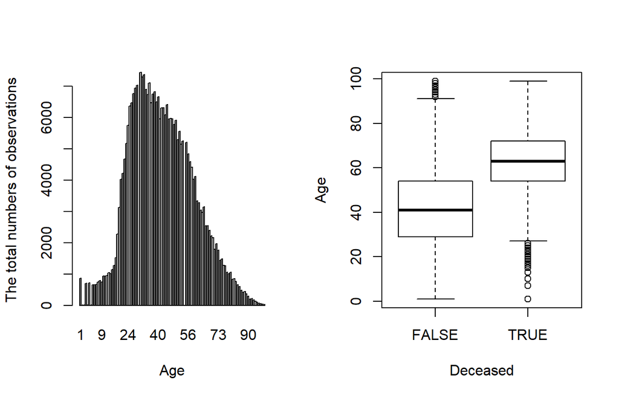

```r
par(mfrow=c(1, 2))
## Total number of observations across ages
barplot(table(covid.df$years), xlab = "Age", ylab = "The total numbers of observations")
## Visualise relationship between `deceased` and `years`
boxplot(covid.df$years ~ covid.df$deceased, xlab = "Deceased", ylab = "Age")
```

## Commentary:

- There are a large number of observations around age 30 to 50.
- Most of the observations in the “Surviving” group were between ages 25 to 55. And, there are couples of outliers around age 90 to 100.
- Most of the observations in the “Deceased” group were between ages 55 to 70. And, there are couples of outliers around age 1 to 25.
- The age impact seems to be significant in “Deceased”/“Surviving” groups.

# Task 4

Extract a random subset of 80% of the data to use as a training set; the remaining data will be the test set.

```r
## Set Seed so that same sample can be reproduced in future:
set.seed(123)

## Now Selecting 80% of data as sample from total 'n' rows of the data
sample <- sample.int(n = nrow(covid.df), size = floor(0.8*nrow(covid.df)), replace = F)
train <- covid.df[sample, ]
test  <- covid.df[-sample, ]
```

## Commentary:

- We use the set.seed() function to make sure our procedure is reproducible.
- Then, we use the sample_int() function to choose a sample from the numbers of 339,547 rows from the initial data set, and the size of our sample is 80% of the number of rows in the initial data set. By using the floor() function to make sure the size as an integer.
- Finally, we use the selected rows (in the previous step) to subset the original data set as the training set and those non-selected rows to subset the original data set as the test set.

# Task 5

Using the training set, create a plot showing the relationship between `years` and the proportion of patients who are `deceased`.

```r
## Removing NA's in the training set
trainYears <- train$years
trainSubset <- !is.na(trainYears)
## Exploration: the total number of NAs in the 'years' variable of the trainning dataset (22,451):
sum(is.na(trainYears))
```

```
## [1] 22451
```

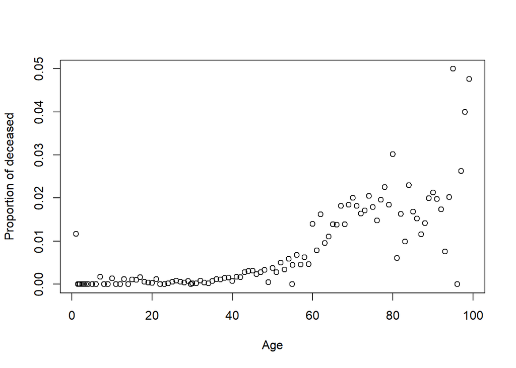

```r
## Subsetting
xTrain <- trainYears[trainSubset]
yTrain <- train$deceased[trainSubset]
fitMean <- mean(yTrain, na.rm=TRUE)

## Visualise relationship between `deceased` and `years`
ct <- table(xTrain, yTrain)
TrainProps <- ct[,2]/rowSums(ct)
plot(as.numeric(rownames(ct)), TrainProps , xlab = "Age", ylab = "Proportion of deceased")
```

## Commentary:

- There were 22,451 missing values in the `years` variable of the training dataset.
- The plot shows that as age increases, the proportion of deceased increases, especially there is a rapid increase in deceased proportion after age 60.

# Task 6 (Model fitting using a training set)

Using the training set, fit a logistic regression model to predict the probability of death based on age.

```r
fitGLM <- glm(y ~ x, data.frame(x=xTrain, y=yTrain), family="binomial",
              na.action=na.exclude)
summary(fitGLM)
```

```
##
## Call:
## glm(formula = y ~ x, family = "binomial", data = data.frame(x = xTrain,
##     y = yTrain), na.action = na.exclude)
##
## Deviance Residuals:
##     Min       1Q   Median       3Q      Max
## -0.3695  -0.0966  -0.0653  -0.0455   4.1380
##
## Coefficients:
##              Estimate Std. Error z value Pr(>|z|)
## (Intercept) -8.621514   0.113459  -75.99   <2e-16 ***
## x            0.060315   0.001767   34.14   <2e-16 ***
## ---
## Signif. codes:  0 '***' 0.001 '**' 0.01 '*' 0.05 '.' 0.1 ' ' 1
##
## (Dispersion parameter for binomial family taken to be 1)
##
##     Null deviance: 13351  on 249185  degrees of freedom
## Residual deviance: 12130  on 249184  degrees of freedom
## AIC: 12134
##
## Number of Fisher Scoring iterations: 9
```

## Commentary:

# Task 7 (Model evaluation using a test set)

Evaluate the model on the test set and compare its performance to a simple overall proportion.

```r
## Removing NA's in the test set
testYears <- test$years
testSubset <- !is.na(testYears)
## Exploration: the total number of NAs in the 'years' variable of the test dataset (5,654):
sum(is.na(testYears))
```

```
## [1] 5654
```

```r
## Subsetting
xTest<- testYears[testSubset]
yTest <- test$deceased[testSubset]

## The simple overall proportion
predProp <- mean(yTrain, na.rm=TRUE)
## Predictions
predGLM <- predict(fitGLM, data.frame(x=xTest), type="response")
## Evaluate ('y' should be 1 or 0 [or TRUE/FALSE])
LogLoss <- function(p, y) {
    -mean(y*log(p) + (1 - y)*log(1 - p))
}
LogLoss(predProp, yTest)
```

```
## [1] 0.02695889
```

```r
LogLoss(predGLM, yTest)
```

```
## [1] 0.0246616
```

## Commentary:

- There were 5,654 missing values in the `years` variable of the test dataset.
- The predictions based on our model seem to perform better (smaller log loss) compared to the one using the simple overall proportion.

# Task 8

Using the test set, create a plot showing the relationship between `years` and the proportion of patients who are `deceased`, with a line indicating the predictions of the model.

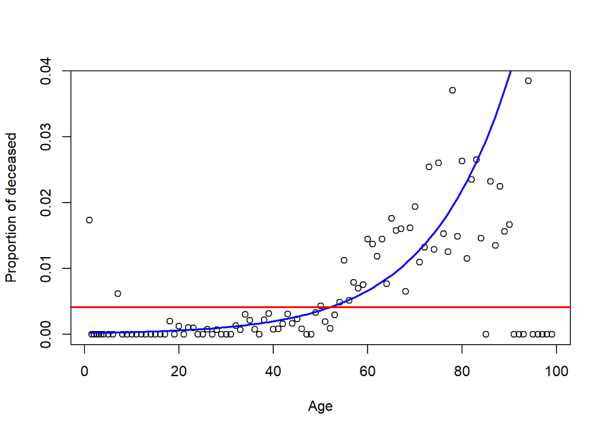

```r
## Visualize
ct2 <- table(xTest, yTest)
TestProps <- ct2[,2]/rowSums(ct2)
plot(as.numeric(rownames(ct2)), TestProps, xlab = "Age", ylab = "Proportion of deceased")
o <- order(xTest)
lines(xTest[o], predGLM[o], col = "blue", lwd = 2)
abline(h=predProp, col="red", lwd=2)
```

## Commentary:

The model captures most of the data, but some observations around age 90 to 100 are left behind. We may need two different models, for example, one model with people aged less than 60 and the other with people aged greater than 60 to illustrate the relationship between the age and proportion of the deceased.

# Conclusion